# Session 09 Support Vector Machines

[**CCMVI2085U Machine Learning for Predictive Analytics in Business @ CBS ISUP 2020**](https://kursuskatalog.cbs.dk/2019-2020/KAN-CCMVI2085U.aspx?lang=en-GB)

Course coordinator: [Bowei Chen](https://boweichen.github.io/) | Email: bc.acc@cbs.dk

Support vector machine (SVM) is a supervised learning method, can be used for solving classification and regression problems. It is a technique has its roots in statistical learning theory and has shown promising empirical results in many practical applications.

# Table of Contents

## Maximum margin classifier

### Notations

Let's set up the mathematical notations at the beginning. We denote the dataset $\mathscr{D}$, where

$$\mathscr{D} = \{(\boldsymbol{x}_1, y_1), \cdots, (\boldsymbol{x}_N, y_N)\} = \{(\boldsymbol{x}_n, y_n)\}_{n=1}^{N}$$$$ \boldsymbol{X} = \left[ \begin{array}{ccc} x_{11} & \cdots & x_{1D} \\ \vdots & \ddots & \vdots \\ x_{N1} & \cdots & x_{ND} \\ \end{array} \right] = \left[ \begin{array}{c} \boldsymbol{x}_1^\top \\ \vdots\\ \boldsymbol{x}_N^\top \\ \end{array} \right] , \ \ \ \ \ \boldsymbol{y} = \left[ \begin{array}{ccc} y_{1} \\ \vdots \\ y_{N} \\ \end{array} \right]$$

### What is a hyperplane?

Let's revisit the example in logistic regression.

Suppose we are marketing analysts and working with a client company -- a credit card company which wants to advertise its credit card offer to Amazon‘s users. The company buys a dataset from Amazon. It contains some Amazon users’ recent purchase spending amounts, age and their responses (i.e., clicking) towards online advertisements. The credit card company wants to develop a prediction model to predict whether an Amazon user would be willing to click or not on its credit card banner advertisement

[figure not shown]

|  | Spending | Age | Click |
| --- | --- | --- | --- |
| 0 | 9.5 | 14 | 0 |
| 1 | 20.2 | 21 | 1 |
| 2 | 9.7 | 10 | 0 |
| 3 | 18.3 | 14 | 1 |
| 4 | 12.2 | 15 | 1 |

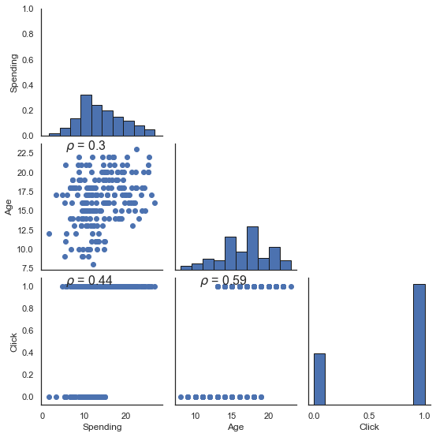

In the scatter plot, we can add the labels as into legend. Now can we use a straight line to seperate positive and negative samples? If we can find a such line and this line is the so-called hyperplane.

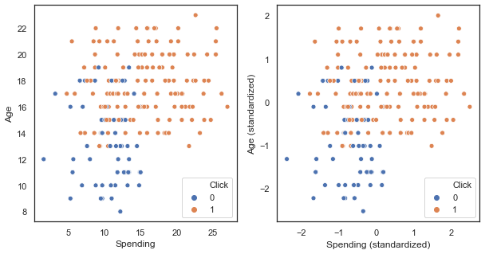

In a $D$-dimensional space, a **hyperplane** is a flat affine subspace of dimension $D − 1$.

Here the term affine indicates that the subspace need not pass through the origin.

- In two dimensions, a hyperplane is a flat one-dimensional subspace, in other words, a line.
- In three dimensions, a hyperplane is a flat two-dimensional subspace that is, a plane.
- In $D > 3$ dimensions, it can be hard to visualize a hyperplane, but the notion of a $(D − 1)$-dimensional flat subspace still applies.

Let $h(\boldsymbol{x})$ denote the **hyperplane function**, given by $$ h(\boldsymbol{x}) = \boldsymbol{w}^\top \boldsymbol{x} + b = w_1 x_1 + \cdots + w_D x_D + b, $$ where $\boldsymbol{w}$ is a $D$-dimensional weight vector and $b$ is the bias. The hyperplane satisfies the equation $h(\boldsymbol{x}) = 0$.

Note: the lowercase bold letter $\boldsymbol{x}_n$ denotes the nth feature vector; the lowercase letter $x_d$ denotes the value of feature/variable $d$ for a given vector.

For example, in two dimensions, a hyperplane is defined by the equation $$ w_1 x_1 + w_2 x_2 + b = 0. $$

If $w_1 = 2$, $w_2 = 3$, and $b=1$, then the hyperplane $2 x_1 + 3 x_2 + 1 = 0$ is shown below. The blue region is the set of points for which $2 x_1 + 3 x_2 + 1 > 0$, and the purple region is the set of points for which $2 x_1 + 3 x_2 + 1 < 0$.

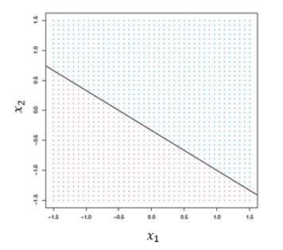

### Classification using a separating hyperplane

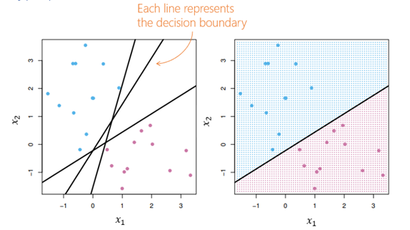

We can label the instance from the blue class as $y_n = 1$ and those from the purple class as $y_n = −1$. Then a separating hyperplane has the property that

$$ y = \begin{cases} +1, \text{ if } h(\boldsymbol{x})>0, \\ -1, \text{ if } h(\boldsymbol{x})<0. \end{cases} $$

Therefore, the classifier is $$ f(\boldsymbol{x}) = \text{sign}(h(\boldsymbol{x})) = \text{sign}(\boldsymbol{w}^\top \boldsymbol{x} + b). $$

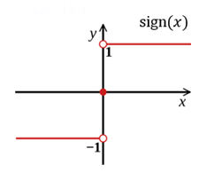

### Optimal separating hyperplane

As we can see there are many separating hyperplanes in the above toy example, the next question we need to consider in classification is that which separating hyperplane is the best. The best/optimal separating hyperplane is the one which is farthest from the training observations. That is, we can compute the (perpendicular) distance from each training observation to a given separating hyperplane; the smallest such distance is the minimal distance from the observations to the hyperplane, and is known as the **margin**.

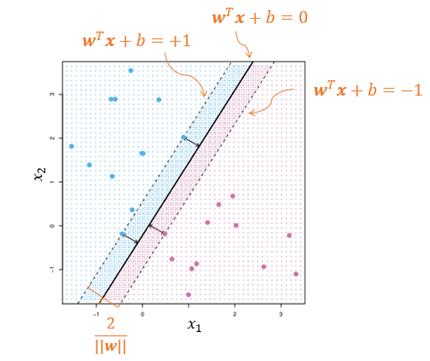

The **maximal margin hyperplane** is shown as a solid line. The margin is the distance from the solid line to either of the dashed lines. The two blue points and the purple point that lie on the dashed lines are the **support vectors**. The purple and blue grid indicates the decision rule made by a classifier based on this separating hyperplane.

For any point $\boldsymbol{x}$, its distance to the hyperplane can be written as $$ \frac{\mid \boldsymbol{w}^\top \boldsymbol{x} + b\mid}{\parallel \boldsymbol{w}\parallel} $$

Therefore, we can formulate the maximal margin hyperplane as the solution to the following optimization problem

\begin{align*} \max_{\boldsymbol{w}, b} & \ \ \frac{2}{\parallel\boldsymbol{w}\parallel} \\ \text{s.t.} & \ \ y_n (\boldsymbol{w}^\top \boldsymbol{x}_n + b) \geq 1, \forall \boldsymbol{x}_n \in \mathscr{D}\\ \end{align*}

The above optimization problem is equivalent to

\begin{align*} \min_{\boldsymbol{w}, b} & \ \ \frac{1}{2} \parallel\boldsymbol{w}\parallel^2 \\ \text{s.t.} & \ \ y_n (\boldsymbol{w}^\top \boldsymbol{x}_n + b) \geq 1, \forall \boldsymbol{x}_n \in \mathscr{D}\\ \end{align*}

The above optimization is a convex quadratic programming problem.

## Soft margin classifier

So far we assume that the data is perfectly linearly separable. However, this is an very ideal situtation. In many problems, classes have overlap to some extent so that a perfect separation is not possible. SVM can handle the non-separable points by introducing **slack variables** $\xi_n$, that is

$$ y_n (\boldsymbol{w}^\top \boldsymbol{x}_n + b) \geq 1 - \xi_n, $$

where $\xi_n \geq 0$ is the slack variable for point $\boldsymbol{x}_n$. It shows how much the point can violate the separability condition.

The SVM optimization problem is then

\begin{align*} \min_{\boldsymbol{w}, b, \xi_n} & \ \ \left\{\frac{1}{2}\parallel\boldsymbol{w}\parallel^2 + C \sum_{n=1}^{N} \xi_n^p \right\}\\ \text{s.t.} & \ \ \ y_n (\boldsymbol{w}^\top \boldsymbol{x}_n + b) \geq 1 - \xi_n, \forall \boldsymbol{x}_n \in \mathscr{D}\\ & \ \ \ \xi_n \geq 0, \forall \boldsymbol{x}_n \in \mathscr{D}, \end{align*}

where $p$ and $C$ are constants. The term $\sum_{n=1}^{N} \xi_n^p$ specifies the loss -- the deviation from the separable case and $C$ controls the trade-off between maximizing the margin and minimizing the loss.

## Kernel tricks

The linear support vector classifier can be used for data with a nonlinear decision bounary via the kernel tricks. The idea is to map the original $D$-dimensional points $\boldsymbol{x}_n$ in the input space to points $\phi(\boldsymbol{x}_n)$ in a feature space via some nonlinear transformation $\phi$. Then

$$ h(\boldsymbol{x}) = \boldsymbol{w}^\top \phi(\boldsymbol{x}_n) + b $$

The SVM optimization problem then becomes

\begin{align*} \min_{\boldsymbol{w}, b, \xi_n} & \ \ \left\{\frac{1}{2} \parallel\boldsymbol{w}\parallel^2 + C \sum_{n=1}^{N} \xi_n^p \right\}\\ \text{s.t.} & \ \ \ y_n (\boldsymbol{w}^\top \phi(\boldsymbol{x}_n) + b) \geq 1 - \xi_n, \forall \boldsymbol{x}_n \in \mathscr{D}\\ & \ \ \ \xi_n \geq 0, \forall \boldsymbol{x}_n \in \mathscr{D} \end{align*}

Sovling the above optimization, we have

\begin{align*} h(\boldsymbol{x}) = & \ \boldsymbol{w}^\top \phi(\boldsymbol{x}_n) + b \\ = & \ \sum_{n=1}^{N} \alpha_n y_n \phi(\boldsymbol{x}_n)^\top \phi(\boldsymbol{x}) + b \\ = & \ \sum_{n=1}^{N} \alpha_n y_n \kappa(\boldsymbol{x}_n, \boldsymbol{x}) + b, \end{align*}

where $\alpha_n$ is the Lagrange multiplier for each constraint and $\kappa(\cdot, \cdot)$ is the **kernal function**.

The following are popular kernels

| Kernel | $k(\boldsymbol{x}_n, \boldsymbol{x}_m)$ |
| --- | --- |
| Linear | $\boldsymbol{x}_n^\top \boldsymbol{x}_m$ |
| Polynomial | $(\alpha \boldsymbol{x}_n^\top \boldsymbol{x}_m + r)^d$ |
| Sigmoid | $\tanh(\alpha \boldsymbol{x}_n^\top \boldsymbol{x}_m + r)$ |
| Gaussian | $e^{-\frac{\parallel\boldsymbol{x}_n - \boldsymbol{x}_m\parallel^2}{2 \sigma^2}}$ |
| Radial basis function (RBF) | $e^{-\frac{\parallel\boldsymbol{x}_n - \boldsymbol{x}_m\parallel^2}{\gamma}}$ |

With kernel, we can predict the class for a new point $\boldsymbol{z}$ as follows

\begin{align*} \hat{y} & \ = \text{sign}(\boldsymbol{w}^\top \phi(\boldsymbol{z})+b) \\ & \ = \text{sign} \left(\sum_{\alpha_n >0} \alpha_n y_n \phi(\boldsymbol{x}_n)^\top \phi(\boldsymbol{z}) + b \right) \\ & \ = \text{sign} \left(\sum_{\alpha_n >0} \alpha_n y_n k(\boldsymbol{x}_n, \boldsymbol{z}) + b \right) \end{align*}

## One-vs-rest & one-vs-one

For a multi-class classification problem, if we know the density $p_k(x)$ for each class $k$ in $K$ classes, then we can predict by

$$ \text{argmax}_{k \in \{1,...,K\}} p_k(\boldsymbol{x}) $$

However, it is very difficult to estimate the densities.

There are two general approaches for us to extend the two-class classification models to solve the multi-class task:

- One-vs-rest (OvR) method. In some references, it is also called one-vs-all (OvA) method.
- One-vs-one (OvO) method. In some references, it is also called all-vs-all (AvA) method.

### One-vs-rest

**Input**: $\mathscr{D} = \{(\boldsymbol{x}_1, y_1), (\boldsymbol{x}_2, y_2), \ldots, (\boldsymbol{x}_N, y_N)\}$  
Learner $f$ (for two-class classification)  
**Process**:  
1: **for** $k = 1, \ldots, K$: # Total $K$ classes  
2: **Construct** a new label vector $\boldsymbol{z}$ for all instance in $\mathscr{D}$ where $z_{n} = 1$ if $y_n = k$ otherwise $z_n = 0$  
3: **Train** a learner $f_k$ based on $\{(\boldsymbol{x}_n, z_n)\}_{n=1}^{N}$  
**Output**: $\text{argmax}_{k \in \{1,...,K\}} f_k(\boldsymbol{x})$

This approach is commonly used for algorithms that naturally predict numerical class membership probability or score such as logistic regression

### One-vs-one

**Input**: $\mathscr{D} = \{(\boldsymbol{x}_1, y_1), (\boldsymbol{x}_2, y_2), \ldots, (\boldsymbol{x}_N, y_N)\}$  
Learner $f$ (for two-class classification)  
**Process**:  
1: **Train** $K(K-1)/2$ learners, where a learner $f_{kj}$ classifies data for class $k$ and class $j$ and $j \neq k$  
**Output**: $\text{argmax}_{k \in \{1,...,K\}} \sum_{j} f_{kj}(\boldsymbol{x})$

This approach is suggested for SVM and related kernel-based algorithms. In the `sklearn` library, the SVM uses the one-vs-one method for multi-class classification problems.

## Implementing SVMs in Python

In terms of classification, the `sklearn` library provides three classes under its `svm` module:

- `LinearSVC`: https://scikit-learn.org/stable/modules/generated/sklearn.svm.LinearSVC.html
- `NuSVC`: https://scikit-learn.org/stable/modules/generated/sklearn.svm.NuSVC.html
- `SVC`: https://scikit-learn.org/stable/modules/generated/sklearn.svm.SVC.html

Let's revisit this holiday event business project!

Suppose we are analysts working with a client – a large seaside resort company whose business is to provide affordable holiday family fun activities and entertainments. The company would like us to develop a model which can recommend this summer’s events (e.g., spa, shows, and outdoor activities) to the booked customers (i.e., booked flats). Our goal is to develop a data-driven model which can segment customers from the last summer’s data and use it to recommend events to this summer’s new bookings.

[figure not shown]

```
import pandas as pd

df = pd.read_csv("data/Holiday_Rental_Consumer_Segmentation.csv")
df.head()
```

|  | Price | Size | Bedroom | Bathroom | Floor | Car_Parking | Internet | Location | Pet | Event |
| --- | --- | --- | --- | --- | --- | --- | --- | --- | --- | --- |
| 0 | 420.0 | 292.5 | 3 | 1 | 2 | Yes | No | Area_2 | No | Spa |
| 1 | 660.0 | 208.0 | 3 | 1 | 1 | Yes | No | Area_1 | No | Spa |
| 2 | 660.0 | 194.0 | 3 | 2 | 2 | Yes | No | Area_3 | No | Spa |
| 3 | 838.0 | 240.0 | 3 | 1 | 1 | Yes | No | Area_1 | No | Spa |
| 4 | 900.0 | 360.0 | 3 | 2 | 1 | Yes | No | Area_4 | No | Spa |

```
from sklearn.preprocessing import StandardScaler
from sklearn import preprocessing

x = pd.get_dummies(df.iloc[:, :-1], drop_first=True).to_numpy()
ss = StandardScaler().fit(x[:, :5])
x[:, :5] = ss.transform(x[:, :5])

le = preprocessing.LabelEncoder().fit(df["Event"])
y = le.transform(df["Event"])
```

```
from sklearn.model_selection import train_test_split

random_seed_val = 100

x_train, x_test, y_train, y_test = train_test_split(
    x, y, test_size=0.5, stratify=y, random_state=random_seed_val
)
```

```
from sklearn import svm
from sklearn.metrics import classification_report

svm_clf = svm.SVC(kernel="rbf", decision_function_shape="ovr")
svm_clf.fit(x_train, y_train)
y_pred_test = svm_clf.predict(x_test)
print(classification_report(y_test, y_pred_test))
```

```
              precision    recall  f1-score   support

           0       1.00      0.30      0.46        10
           1       0.89      0.61      0.72        28
           2       0.76      0.97      0.85        58

    accuracy                           0.79        96
   macro avg       0.88      0.62      0.68        96
weighted avg       0.82      0.79      0.77        96
```